# NYC Airbnb Market Analysis

Antoine, Charles, Mokhmad

## Introduction

This report explores the dynamics of the Airbnb market in New York City using a public dataset. The objective is to better understand price patterns, geographical trends, and the factors that influence rental values across the city.

# Understanding the Dataset

The dataset gathers detailed information about Airbnb listings across New York City. It covers variables related to pricing, location, property type, and host activity, providing a rich foundation to understand market dynamics.

Before any analysis, the dataset is inspected to assess its structure and scope.

Dataset overview: size and scope

| Number of observations | Number of variables |
| --- | --- |
| 48895 | 16 |

Variables available in the dataset

| Column names |
| --- |
| id |
| name |
| host_id |
| host_name |
| neighbourhood_group |
| neighbourhood |
| latitude |
| longitude |
| room_type |
| price |
| minimum_nights |
| number_of_reviews |
| last_review |
| reviews_per_month |
| calculated_host_listings_count |
| availability_365 |

Data Quality and Preparation

To ensure a reliable foundation for the analysis, several adjustments were made:

- Temporal data: the variable last_review was converted into a valid date format to allow time-based exploration.
- Missing information: listings with no reviews had missing values for reviews_per_month; these were replaced by 0, meaning no activity.
- Unrealistic values: listings with a price of 0 were removed, as such prices are not representative of the market.
- Non-relevant identifiers: variables like id, host_id, and host_name were excluded to focus on analytical information.

After these steps, the dataset is now consistent, cleaned, and ready for exploration.

Dataset after cleaning and preparation

| Observations after cleaning | Variables after cleaning |
| --- | --- |
| 48884 | 13 |

## Market Overview

The cleaned dataset now provides a clear view of the Airbnb market across New York City.  
This section explores the overall composition of the listings and the main factors that shape price dynamics.

### General Distribution of Listings

Most listings are concentrated in Manhattan and Brooklyn, which also represent the most active and expensive areas in the city.  
Understanding how listings are distributed geographically helps identify the core zones of Airbnb activity.

Distribution of listings and average price by borough

| neighbourhood_group | listings | avg_price |
| --- | --- | --- |
| Manhattan | 21660 | 196.88490 |
| Brooklyn | 20095 | 124.43892 |
| Queens | 5666 | 99.51765 |
| Bronx | 1090 | 87.57706 |
| Staten Island | 373 | 114.81233 |

## Visualization and Spatial Analysis

This section explores how Airbnb listings are distributed across New York City and how prices vary depending on location and room type. One interactive map lets users zoom in and explore Airbnb listings, displaying the name of each property.

[interactive chart not shown]

## Availability and Demand

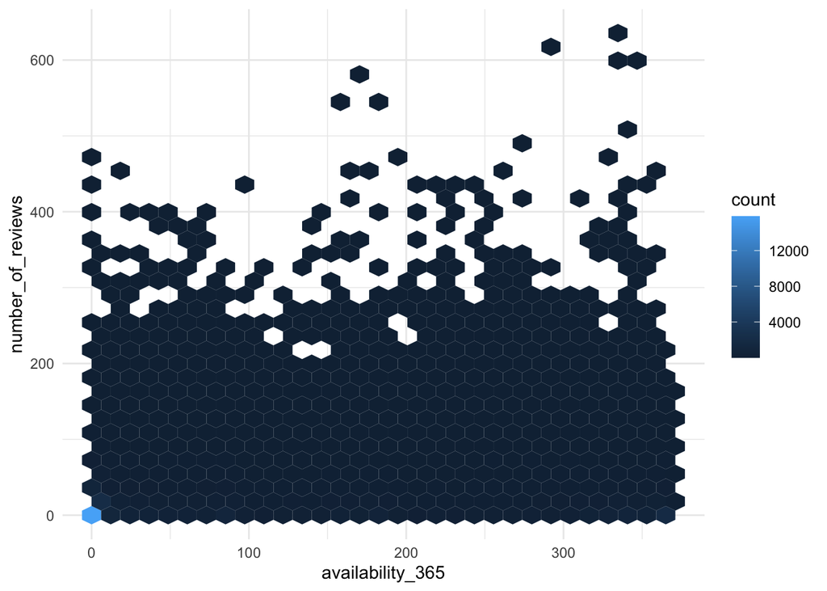

## Room Type Distribution

Entire homes and private rooms dominate the market, showing that most hosts rent full apartments or personal spaces rather than shared ones.

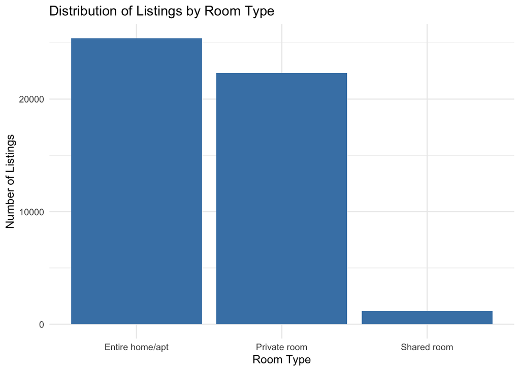

## Price Differences by Area

Manhattan and Brooklyn show the highest median prices, confirming their position as the most expensive and in-demand areas of the city.

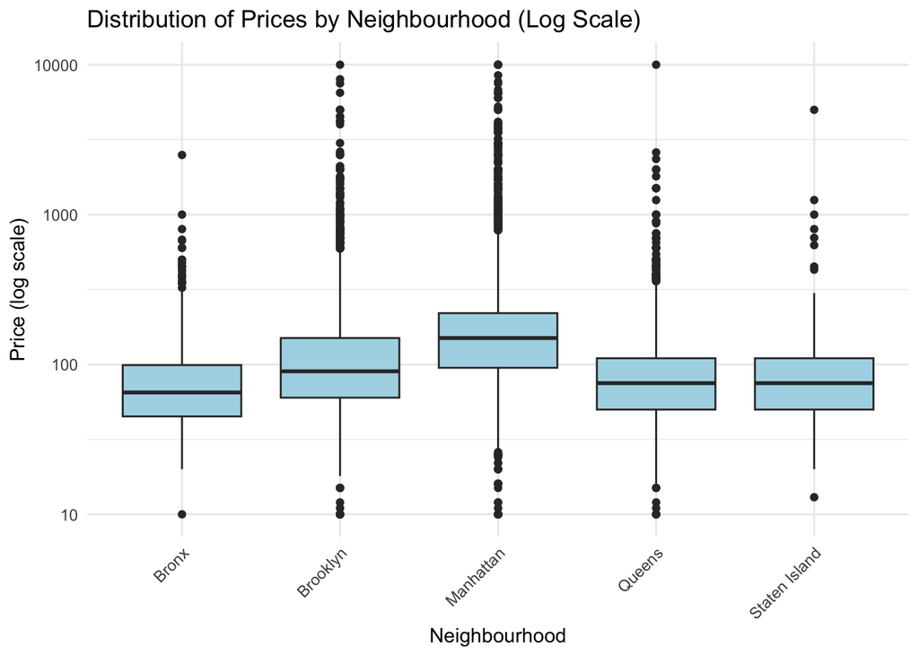

## Neighbourhood-Level Insights

These boxplots show how prices vary inside each borough. Even within the same area, some neighbourhoods stand out with much higher prices, especially in Manhattan and parts of Brooklyn.

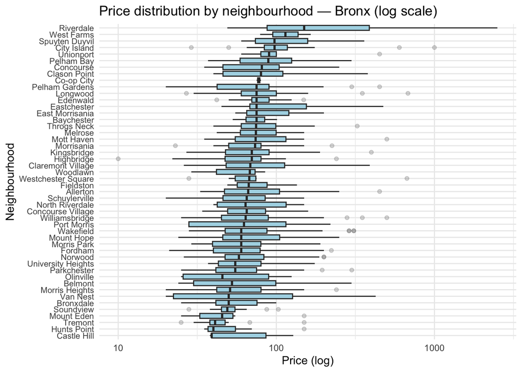

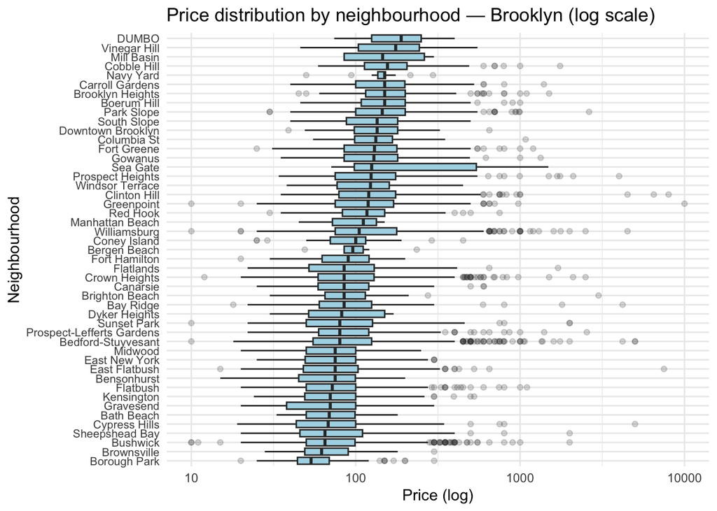

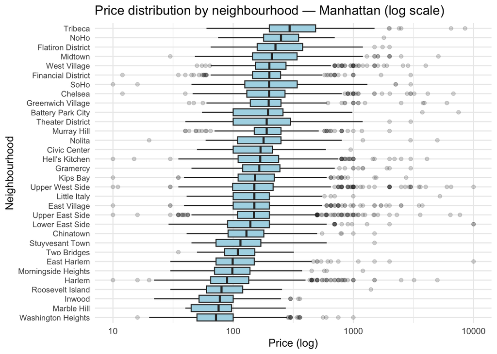

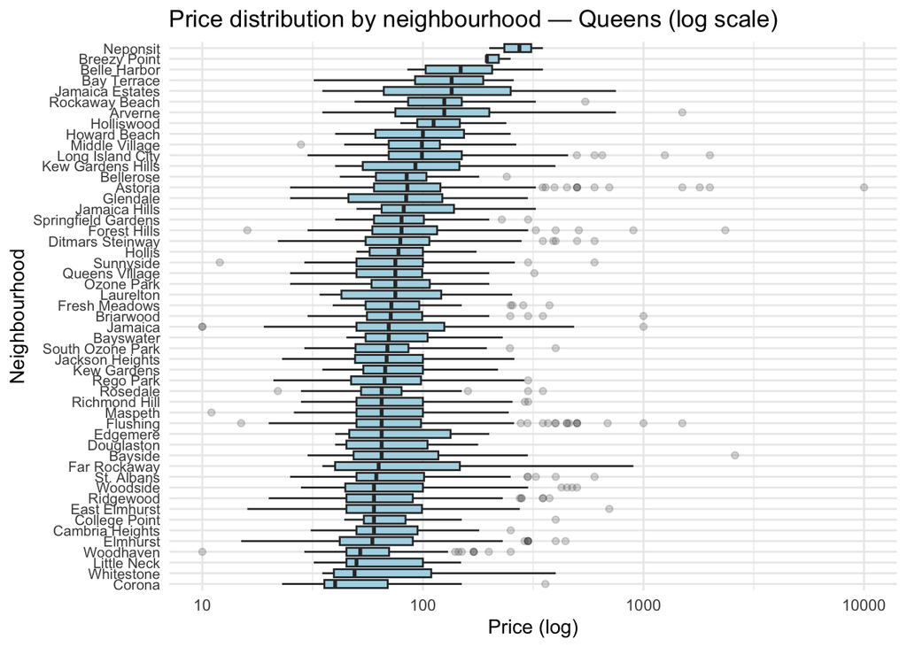

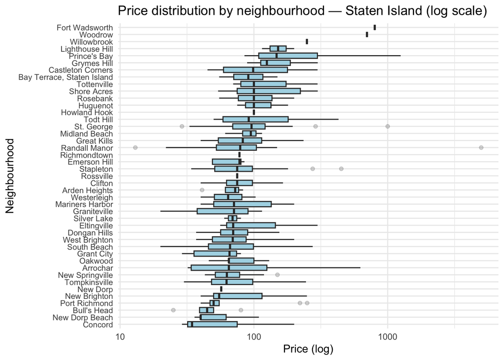

# Predictive Modeling

This final part focuses on predicting Airbnb prices based on location, room type, and customer activity. Two models are tested : a linear regression and a regression tree to compare their accuracy and understand which factors most influence price variation across New York City.

The dataset is now prepared for modeling, with key variables formatted and the data split into training and test sets to build and evaluate price prediction models.

## Linear Regression Model

A linear regression model is trained to estimate how each factor — location, room type, and number of reviews impacts the price. Positive coefficients indicate a price increase, while negative ones show a decrease relative to the baseline.

## Regression Tree (with pruning)

We train a regression tree to capture non-linear price patterns and interactions between location and room type. The tree is pruned using cross-validation to prevent overfitting and keep only the splits that improve out-of-sample accuracy.

Both models are now tested on unseen data to evaluate how well they can predict Airbnb prices based on key factors such as location, room type, and customer activity.

To evaluate model accuracy, we use the Root Mean Squared Error (RMSE), which measures how far predicted prices deviate from real Airbnb prices.

Lower values indicate better performance and more reliable predictions.

Model performance comparison (lower RMSE = better)

| Model | RMSE |
| --- | --- |
| Linear Regression | 259.66 |
| Regression Tree | 259.90 |

The two regression models both show an RMSE of around $260, indicating a rather large prediction error. With a first quartile of $69 and a median of $106, the gap between predicted and actual prices remains significant — suggesting that both models capture only part of the market complexity and would need improvement to achieve acceptable accuracy levels.

To better interpret the linear regression model, we translate each coefficient into a percentage impact on price. Positive values indicate factors that increase the average price, while negative ones represent elements that tend to lower it.

Estimated percentage influence of each factor on Airbnb price

| Variable | Influence on Price (%) |
| --- | --- |
| Brooklyn | 23.26 |
| Manhattan | 70.68 |
| Queens | 10.71 |
| Staten Island | 4.84 |
| Private Room | -53.42 |
| Shared Room | -67.28 |

The variable importance values highlight which factors such as location or room type play the biggest role in determining Airbnb prices.

Relative influence of each factor in the regression tree model

| Variable | Relative Importance (%) |
| --- | --- |
| room_type | 76.4 |
| neighbourhood_group | 22.5 |
| number_of_reviews | 1.0 |

This means that Airbnb prices in New York are mainly driven by the type of accommodation and its location, while guest activity (reviews) has a marginal impact.